```r
library(FlashGraphR)
fg.set.conf("/mnt/nfs2/zhengda/FlashX/matrix/conf/run_test-EM.txt")
```

# The degree distribution in the Page Graph

```
[1] "get a graph"
```

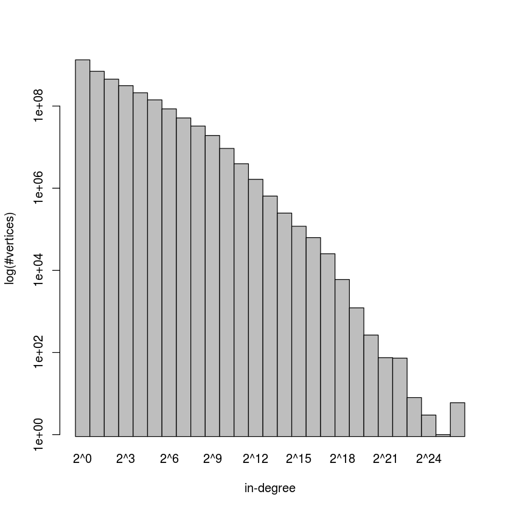

```r
fg <- fg.get.graph("page-graph-compact")
deg <- fg.degree(fg, mode="in")
fm.hist(deg, breaks="exp", log="y", xlab="in-degree", ylab="log(#vertices)")
```

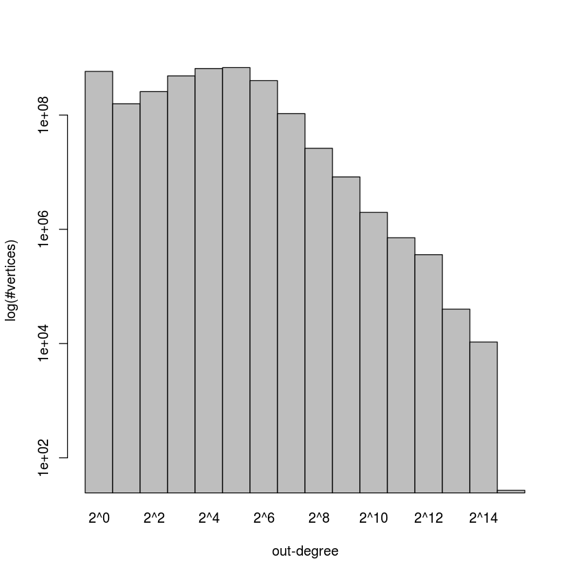

```r
deg <- fg.degree(fg, mode="out")
fm.hist(deg, breaks="exp", log="y", xlab="out-degree", ylab="log(#vertices)")
```

# The screeplot of the singular values

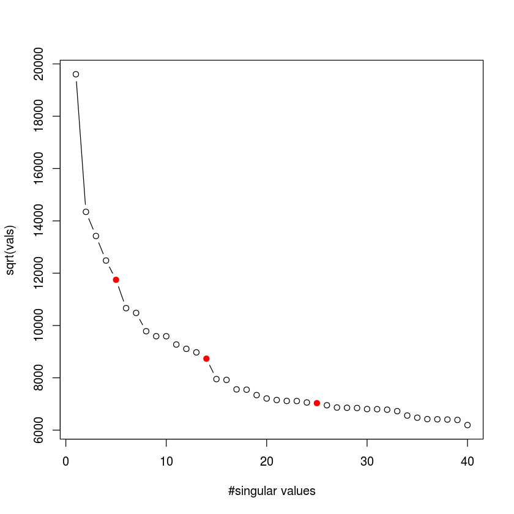

```r
load("/mnt/nfs2/zhengda/pg-aug-40.vals")
getElbows <- function(d, n = 3, threshold = FALSE)
{
  if (is.unsorted(-d))
    stop("d must be sorted decreasingly!")

  if (!is.logical(threshold))
    d <- d[d > threshold]

  p <- length(d)
  if (p == 0)
    stop(paste("d must have elements that are larger than the threshold ",
               threshold), "!", sep="")

  lq <- rep(0.0, p)                     # log likelihood, function of q
  for (q in 1:p) {
    mu1 <- mean(d[1:q])
    mu2 <- mean(d[-(1:q)])              # = NaN when q = p
    sigma2 <- (sum((d[1:q] - mu1)^2) + sum((d[-(1:q)] - mu2)^2)) /
      (p - 1 - (q < p))
    lq[q] <- sum( dnorm(  d[1:q ], mu1, sqrt(sigma2), log=TRUE) ) +
      sum( dnorm(d[-(1:q)], mu2, sqrt(sigma2), log=TRUE) )
  }

  q <- which.max(lq)
  if (n > 1 && q < p) {
    return(c(q, q + getElbows(d[(q+1):p], n-1)))
  } else {
    return(q)
  }
}

cols <- rep("black", length(vals))
cols[getElbows(sqrt(vals))] <- "red"
pch <- rep(1, length(vals))
pch[getElbows(sqrt(vals))] <- 19
plot(sqrt(vals), type="b", xlab="#singular values", col=cols, pch=pch)
```

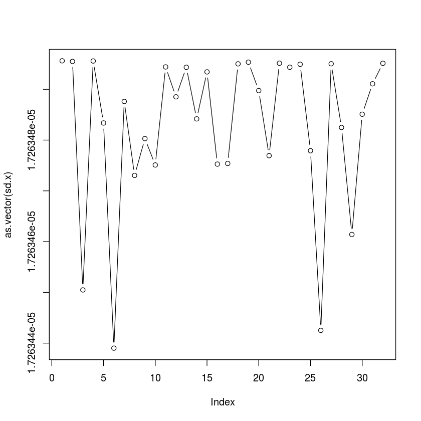

```r
x <- fm.get.dense.matrix("pg-aug-right1to32.mat")
n <- nrow(x)
sum.x2 <- colSums(x * x)
sum.x <- colSums(x)
avg <- sum.x/n
sd.x <- as.vector(sqrt((sum.x2 - n * avg * avg)/(n-1)))
plot(as.vector(sd.x), type="b")
```

# Plot vertices in a 2D plane

Let's assume $U_1$ to be the first singular vector, $V_1$ to be the first right singular vector, $\sigma_1$ to be the first singular value. We use $U_1\sqrt{\sigma_1}$ as the x coordinate and $V_1\sqrt{\sigma_1}$ as the y coordinate of the vertices in a 2D space. We further rotate all vertices to the first quadrant so that the mean of the coordinates of the vertices falls in the line of $y=x$.

```r
svals <- sqrt(vals)
U <- fm.get.dense.matrix("pg-aug-left1to8.mat")
V <- fm.get.dense.matrix("pg-aug-right1to8.mat")

X.in <- U[,1] * sqrt(svals[1])
X.out <- V[,1] * sqrt(svals[1])
X.in <- fm.conv.store(X.in, in.mem=TRUE)
X.out <- fm.conv.store(X.out, in.mem=TRUE)
m <- c(fm.conv.FM2R(mean(X.in)), fm.conv.FM2R(mean(X.out)))
m1 <- rep(sqrt(sum(m*m))/sqrt(2), 2)
cos <- sum(m*m1)/sum(m*m)
sin <- sqrt(1-cos*cos)
proj <- matrix(c(cos,sin,-sin,cos), 2, 2)

coo <- cbind(X.in, X.out)
coo <- fm.materialize(coo %*% proj)
```

Many vertices in the first quadrant fall in a small area beside the origin. Here we illustrate the percentage of the vertices in the small area.

```r
res <- list()
origin.radius <- c(1e-8, 1e-7, 1e-6, 1e-5, 5e-5)
for (val in origin.radius) {
    res <- c(res, abs(coo[,1]) < val & abs(coo[,2]) < val)
}
res <- fm.cbind.list(res)
origin.ratio <- as.vector(colSums(as.double(res)))/nrow(res)
```

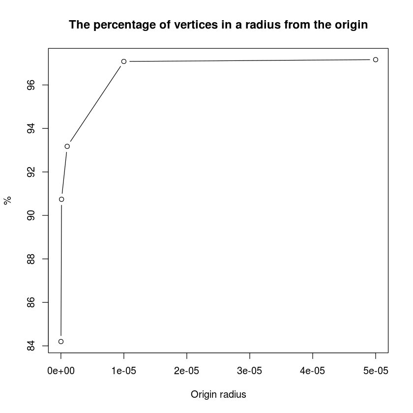

```r
plot(x=origin.radius, y=origin.ratio * 100, type="b", xlab="Origin radius", ylab="%",
     main="The percentage of vertices in a radius from the origin")
```

Because we compute SVD with certain numerical precision, when a vertex is close enough to the origin, we can assume it is in the origin. As such, we can ignore majority of the vertices when we plot the distribution of the vertices.

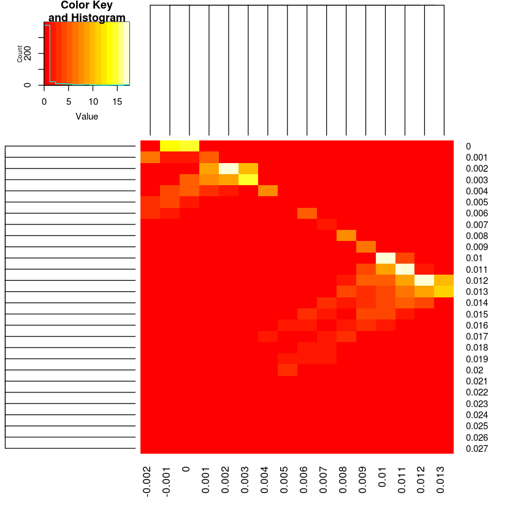

```r
library(gplots)
coo1 <- coo[coo[,1] > -0.002 & abs(coo[,1]) > 1e-5 & abs(coo[,2]) > 1e-5,]
fm.heatmap(coo1, 1000, logval=TRUE)
```

The vertices in the area close to (0.011, 0.011)

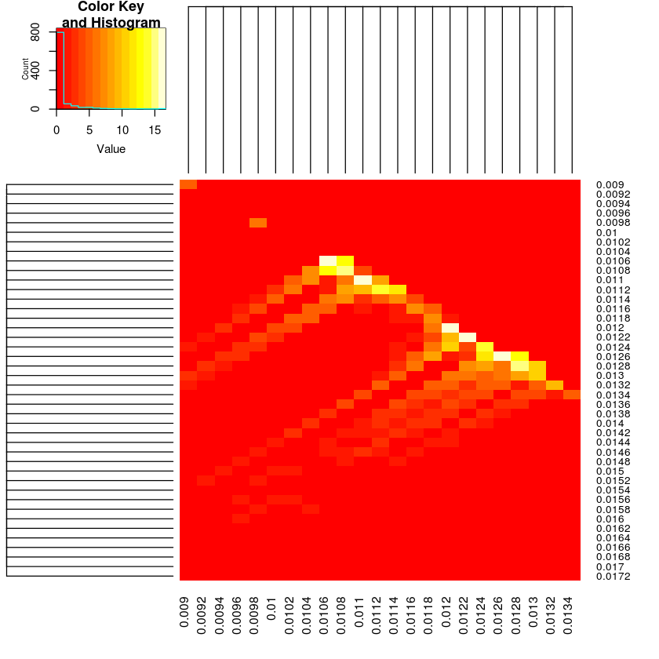

```r
coo2 <- coo1[coo1[,1] > 0.009,]
fm.heatmap(coo2, 5000, logval=TRUE)
```

The vertices in the area close to (0.002, 0.002)

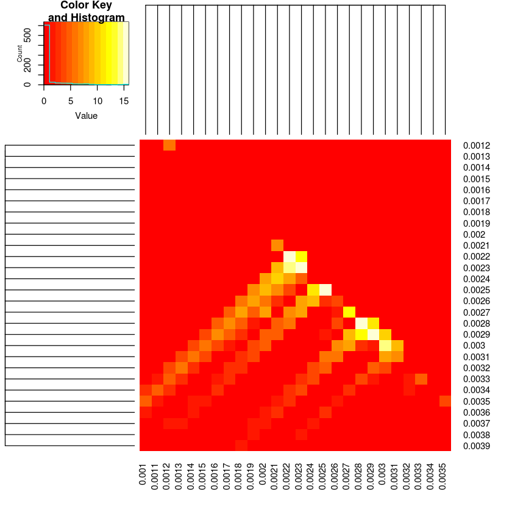

```r
coo3 <- coo1[coo1[,1] > 0.001 & coo1[,1] < 0.004 & coo1[,2] < 0.004,]
fm.heatmap(coo3, 10000, logval=TRUE)
```